# SDS homework 2

Yao wateba Appeti; Haotian zhang

1/17/2021

```r
library('MASS')
library('caTools')
library('caret')
library('mixtools')
library('KScorrect')
```

### Data Generation

```r
set.seed(42)


gen_params <- function(K){
  k = K - 2

  p = c(0.5, rep(0.1,K-1))
  mu    = c(0, ((0:k)/2)-1)
  sigma  = c(1, rep(0.1,K-1))

  return (list(p=p,mu=mu, sigma=sigma))
}

# To generate data of size N and k mixtures
generate_data <- function(N, K){
  k= K - 2
  XX <- rnormmix(N,
             lambda = c(0.5, rep(0.1,K-1)),
             mu     = c(0, ((0:k)/2)-1),
             sigma  = c(1, rep(0.1,K-1)) )
return (XX)
}


## Maybe Usefuls colors
colos <- c(rgb(32/255, 74/255, 135/255, 0.7),
           rgb(204/255, 0, 0, 0.7),
           rgb(200/255, 141/255, 0, 0.7),
           rgb(78/255, 153/255, 6/255, 0.7),
           rgb(32/255, 74/255, 135/255, 0.3),
           rgb(204/255, 0, 0, 0.3),
           rgb(200/255, 141/255, 0, 0.3),
           rgb(78/255, 153/255, 6/255, 0.3))

# Bart data TRUE density
 TRUE.den = function(x) 0.5*dnorm(x, 0, 1) +
                                  0.1*dnorm(x,-1.0, 0.1) + 0.1*dnorm(x, -0.5, 0.1) +
                                  0.1*dnorm(x, 0.0, 0.1) + 0.1*dnorm(x,  0.5, 0.1) +
                                  0.1*dnorm(x, 1.0, 0.1)
```

```r
# Samples sizes
N1 <- 500
N2 <- 100000

# Max num of mixture
kmin = 2
kmax = 10


# Generate data for all mixtures for size N1
N1_data = list()
for (k in kmin:kmax){
  N1_data[[k]] = generate_data(N1, k)
}

# Generate data for all mixtures for size N2
N2_data = list()
for (k in kmin:kmax){
  N1_data[[k]] = generate_data(N2, k)
}
```

For the two samples we co,pute the estimated density , and compare it to the TRUE Bart density . We can see the result on the plot below for the small sample .

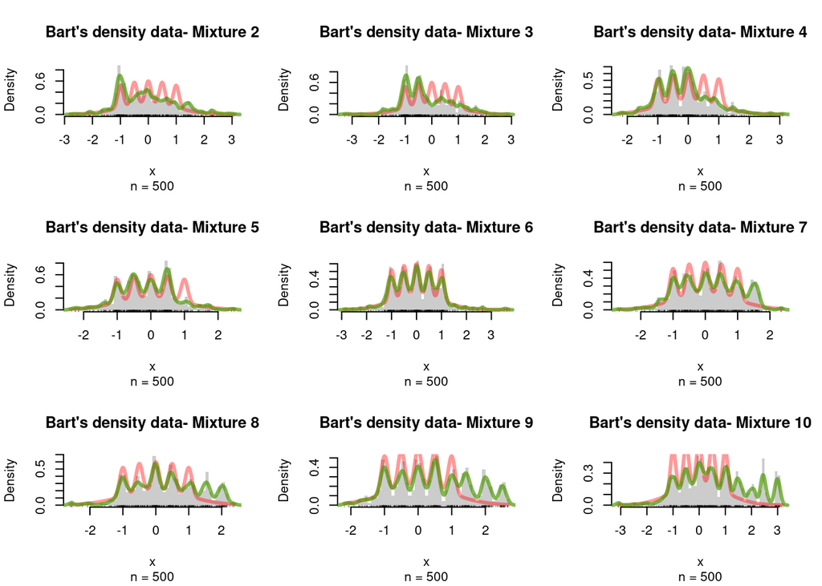

```r
# Histrograms for N1 size
par(mfrow = c(3,3))
for (k in 2:kmax){
  XX = generate_data(N1, k)
  hist(XX, prob = T, col = gray(.8), border = NA, xlab = "x",
     main = paste("Bart's density data- Mixture ",k,sep=""),
     sub = paste("n = ", N1, sep = ""),
     breaks = 50)

  # Show the data points
  rug(XX, col = rgb(0,0,0,.5))

  # Plot the TRUE density
  curve(TRUE.den, col = rgb(1,0,0,0.4), lwd = 3, n = 500, add = TRUE)

  # Kernel density estimate
  # lines(density(XX),            col = colos[3], lwd = 3)   # Oversmoothing
  lines(density(XX, bw = .08),  col = colos[4], lwd = 3)   # Just Right
  # lines(density(XX, bw = .008), col = colos[5], lwd = 3)   # Undersmoothing

  # Add a legend
  # legend("topright", c("TRUE","Over", "Just right", "Under"), lwd = 5,
  #        col = c(rgb(1,0,0,0.4), colos[3], colos[4],colos[5]), cex = 0.8, bty = "n")
  #
}
```

On this small sample using 6 or 7 mixtures seems to reproduce the bart density well enough . To make things clear let reproduce the same thing on a larger sample .

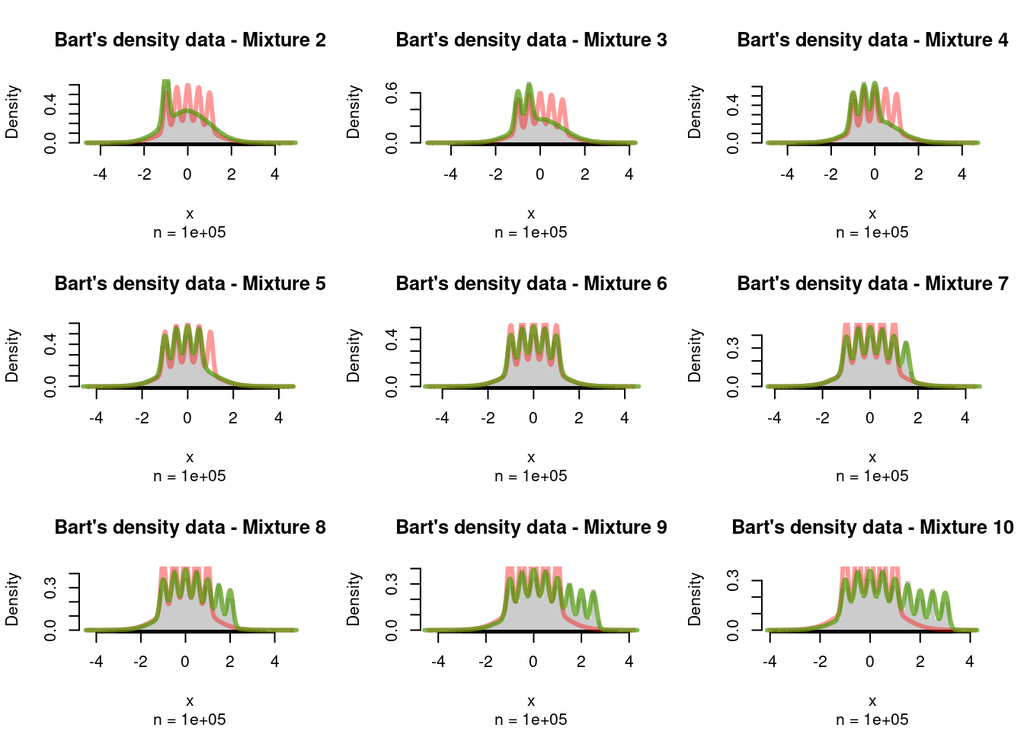

```r
# Histrograms for N2 size
par(mfrow = c(3,3))
for (k in 2:kmax){
  XX = generate_data(N2, k)
  hist(XX, prob = T, col = gray(.8), border = NA, xlab = "x",
     main = paste("Bart's density data - Mixture ",k,sep=""),
     sub = paste("n = ", N2, sep = ""),
     breaks = 50)

    # Show the data points
  rug(XX, col = rgb(0,0,0,.5))

  # Plot the TRUE density
  curve(TRUE.den, col = rgb(1,0,0,0.4), lwd = 3, n = 500, add = TRUE)

  # Kernel density estimate
  # lines(density(XX),            col = colos[3], lwd = 3)   # Oversmoothing
  lines(density(XX, bw = .08),  col = colos[4], lwd = 3)   # Just Right
  # lines(density(XX, bw = .008), col = colos[5], lwd = 3)   # Undersmoothing

  # Add a legend
  # legend("topright", c("TRUE","Over", "Just right", "Under"), lwd = 5,
  #        col = c(rgb(1,0,0,0.4), colos[3], colos[4],colos[5]), cex = 0.8, bty = "n")
  #

}
```

At this point we can see that using 6 components is the best choice . But to prove we will try to fit bart density data with a mixture various gaussian densities to see which one is the best .

#### Handmade EM fit function for k >=2 mixtures

```r
# Function to compute  density and TRUE density on mixtures

compute_density <- function(x,p,mu,sigma){
  nmix = length(mu)
  out = 0
  for (k in 1:nmix){
    out = out +p[k]* dnorm(x,mu[k],sigma[k])
  }

  return(out)
}

# EM function
handmade.em <- function(y, p, mu, sigma, n_iter ,plot_flag = T)
{

  # Number of mixtures
  nmix <- length(p)


  # Init k components
  cols     <- rep(rgb(1,0,0,.3), nmix)
  like <- 0
  for (k in 1:nmix){
    like     <- like + p[k]*dnorm(y, mu[k], sigma[k])
  }
  loglikehood = sum(log(like))
  deviance <- -2*loglikehood

  matrix_num_col = 3*nmix + 2
  res      <- matrix(NA,n_iter + 1, matrix_num_col)
  res[1,]  <- c(0, p, mu, sigma, deviance)
  for (iter in 1:n_iter) {

    #To get out of loop , when predicting
    if(n_iter==0){
      break
    }

    # E step
    d = list()
    d_sum = 0
    for (k in 1:nmix){
      d[[k]] <- p[k]*dnorm(y, mu[k], sigma[k])
      d_sum  <- d_sum + d[[k]]
    }


    r = list()
    for (k in 1:nmix){
      r[[k]] <- d[[k]] / d_sum
    }

    # M step
    for (k in 1:nmix){
      rk <- r[[k]]
      p[k] <- mean(rk)
      mu[k] <- sum(rk*y)/sum(rk)
      sigma[k] <-sqrt( sum(rk*(y^2))/sum(rk) - (mu[k])^2 )
    }

    # -2 x log-likelihood (a.k.a. deviance)
    v_like     <- list()
    like <- 0

    for (k in 1:nmix){
      lk <- p[k]*dnorm(y, mu[k], sigma[k])
      v_like[[k]]     <-  lk
      like <- like + lk
    }

    loglikehood = sum(log(like))
    deviance <- -2*loglikehood

    # Save
    res[iter+1,] <- c(iter, p, mu, sigma, deviance)

    # Plot
    if (plot_flag){
      hist(y, prob = T, breaks = 30, col = gray(.8), border = NA,
           main = "", xlab = paste("EM Iteration: ", iter, "/", n_iter, sep = ""))
      set.seed(123)

      points(jitter(y), rep(0,length(y)),
             pch = 19, cex = .6,
             #col = cols[ (dnorm(y,mu[1],sigma[1]) > dnorm(y,mu[2],sigma[2])) + 1]
             )
      curve(compute_density(x,p,mu,sigma), lwd = 4, col = rgb(0,0,0,.5), add = TRUE)
      curve(TRUE.den, lwd = 4, col = rgb(0,0,0,.5), add = TRUE)
      Sys.sleep(1.5)
    }
  }
  res <- data.frame(res)
  names(res) <- c('Iteration',paste('p',1:nmix, sep=''),paste('mu',1:nmix, sep=''),paste('sigma',1:nmix, sep=''),'Deviance')
  out <- list(parameters = c(p = p, mu = mu,  sigma = sigma),
              deviance = deviance,
              res = res,
              p = p,
              mu = mu,
              sigma=sigma,
              loglik = loglikehood
            )
  return(out)
}
```

```r
require(ggplot2)
require(gridExtra)
plotConvMC <- function(df, title = NULL)
{
  G      <- (ncol(df)-2)/3
  df$rep <- as.factor(df$rep)
  graf   <- vector("list", ncol(df)-2)
  for (j in (2:(ncol(df)-1))) {
    grafj <- ggplot(df) + geom_line(aes_string(df[,1],df[,j],
                                               color = df[,ncol(df)])) +
      xlab("iteration") + ylab(names(df[j])) + theme(legend.position = "none")
    graf[[j-1]] <- grafj
  }
  do.call("grid.arrange", c(graf, ncol = 3, top = title))
}
```

#### Simulation params

```r
set.seed(1234)
M = 100
n_iters = 20
```

### AIC

#### Simulation of small sample

```r
par(mfrow = c(3,3))

best_aic = Inf
aic_best_fit = NULL

# We run simulation
for(k in 2:kmax){
  D.em <- NULL

  for (m in (1:M)) {
    data   = generate_data(N1,6)

    # get params for k mixtures
    p = gen_params(k)$p
    mu     = gen_params(k)$mu
    sigma  = gen_params(k)$sigma

    hem_fit = handmade.em(data, p  ,mu,  sigma ,n_iters, plot_flag = F)

    # AIC is computed using deviance
    aic =  hem_fit$deviance + 2*length(hem_fit$parameters)

    # To handle NaN output
    if (is.nan(aic)){
      aic = Inf
    }
    if (aic < best_aic){
      aic_best_fit = hem_fit
      best_m = k

      #update best aic
      best_aic = aic

    }

  }
}

# summary for best model
summary(aic_best_fit)
```

```
##            Length Class      Mode
## parameters 18     -none-     numeric
## deviance    1     -none-     numeric
## res        20     data.frame list
## p           6     -none-     numeric
## mu          6     -none-     numeric
## sigma       6     -none-     numeric
## loglik      1     -none-     numeric
```

As shown on the results the number of components in the best model is 6 , corresponding to the lowest AIC value.

#### Simulation of large sample

```r
set.seed(1234)
M = 20
kmax = 10
N2 = 100000
best_aic = Inf
aic_best_fit = NULL

# We run simulation
for(k in 2:kmax){
  aics = c()
  for (m in (1:M)) {
    data   = generate_data(N2,6)
    p = gen_params(k)$p
    mu     = gen_params(k)$mu
    sigma  = gen_params(k)$sigma

    hem.fit = handmade.em(data, p  ,mu,  sigma ,n_iter = 20, plot_flag = F)

    aic = hem.fit$deviance + 2*length(hem.fit$parameters)

    if (is.nan(aic)){
      aic = Inf
    }else{
      aics = append(aics,aic)
    }

    if (aic < best_aic){
      aic_best_fit = hem.fit
      best_m = k

      best_aic = aic
    }

  }

  print(paste('k = ',k , ',   AIC = ',mean(aics), sep = ''))
}
```

```
## [1] "k = 2,   AIC = 251256.765291349"
## [1] "k = 3,   AIC = 249281.601273193"
## [1] "k = 4,   AIC = 248207.794329692"
## [1] "k = 5,   AIC = 246251.223092862"
## [1] "k = 6,   AIC = 238531.294352747"
## [1] "k = 7,   AIC = 238811.016355232"
## [1] "k = 8,   AIC = 238541.409700211"
## [1] "k = 9,   AIC = 238831.105859812"
## [1] "k = 10,   AIC = 238599.227544383"
```

```r
# summary for best model

print('summary for best model' )
```

```
## [1] "summary for best model"
```

```r
summary(aic_best_fit)
```

```
##            Length Class      Mode
## parameters 24     -none-     numeric
## deviance    1     -none-     numeric
## res        26     data.frame list
## p           8     -none-     numeric
## mu          8     -none-     numeric
## sigma       8     -none-     numeric
## loglik      1     -none-     numeric
```

The strange thing with the AIC metric on large sample is that it keeps changing for larger values of the sample . Sometimes give 6 components , sometimes 7 or 9. So we cannot conclude on the right number of component at this point . And adding also the mean of all aic computed for every component . It’s point out models with 6 components as best in average. But the best model in absolute has 8 components. So number of components not really clear. Surely for a really high sample the result wil be better, our computation capacities for now doe not allow to test that.

### BIC

#### BIC on small sample

```r
set.seed(1234)
M = 100
kmax = 10
best_bic = Inf
bic_best_fit = NULL

# We run simulation
for(k in 2:kmax){
  D.em <- NULL
  for (m in (1:M)) {

    data   = generate_data(N1,6)

    p = gen_params(k)$p
    mu     = gen_params(k)$mu
    sigma  = gen_params(k)$sigma

    hem_fit = handmade.em(data, p  ,mu,  sigma ,n_iter = 20, plot_flag = F)

    bic = hem.fit$deviance + log(N1)*length(hem.fit$parameters)
    if (is.nan(bic)){
      bic = Inf
    }
    if (bic < best_bic){
      bic_best_fit = hem_fit
      best_bic <- bic

      best_m = k
    }

    # df.em <- hem_fit$res
    # df.em$rep <- m
    # D.em <- rbind(D.em,df.em)
  }
  #plotConvMC(D.em)
}

summary(bic_best_fit)
```

```
##            Length Class      Mode
## parameters 6      -none-     numeric
## deviance   1      -none-     numeric
## res        8      data.frame list
## p          2      -none-     numeric
## mu         2      -none-     numeric
## sigma      2      -none-     numeric
## loglik     1      -none-     numeric
```

Here the best model is obtained for 2 components .

#### BIC on large sample

```r
set.seed(1234)
M = 10
kmax = 10
N2 = 10000
best_bic = Inf
bic_best_fit = NULL

# We run simulation
for(k in 2:kmax){
  D.em <- NULL
  for (m in (1:M)) {
    data   = generate_data(N2,6)
    p = gen_params(k)$p
    mu     = gen_params(k)$mu
    sigma  = gen_params(k)$sigma

    hem_fit = handmade.em(data, p  ,mu,  sigma ,n_iter = 20, plot_flag = F)
    bic = hem_fit$deviance + log(N1)*length(hem_fit$parameters)

    if (is.nan(bic)){
      bic = Inf
    }

    if (bic < best_bic){
      bic_best_fit = hem_fit
      best_bic <- bic

      best_m = k
    }

  }

}

summary(bic_best_fit)
```

```
##            Length Class      Mode
## parameters 18     -none-     numeric
## deviance    1     -none-     numeric
## res        20     data.frame list
## p           6     -none-     numeric
## mu          6     -none-     numeric
## sigma       6     -none-     numeric
## loglik      1     -none-     numeric
```

Testing on a larger dataset , the best model is obtained for 6 components

## Sample splitting

In this part what we do is to fit many time on Bart density generated data , various models with mixture from 2 to 10. We then predict on the test model. Essentially we will use our handmade fit function for one iteration with the parameters provided by the training steps,setting n_iter = 0.

We will simply take in account the deviance returned by our function ; which is a good model fitness metric.

Then for all mixtures we compute the mean of all test deviance to see which mixture has th lowest deviance

That mixture represent the number of component to correctly estimate the model.

```r
# Function to perform sample and fit
sample_and_fit <- function(N, train_size,kmax,M){
  kmin = 2
  all_deviances = c()
for (k in kmin:kmax){
  mixture_deviance = c()
  for (m in 1:M){
    #Generate Bart data
    data   = generate_data(N,6)

    #Partition in train and test set
    intrain <- createDataPartition(y=data,p=train_size,list=FALSE)
    train   <- data[intrain]
    test    <- data[-intrain]

    # Get params for k mixture
    p = gen_params(k)$p
    mu     = gen_params(k)$mu
    sigma  = gen_params(k)$sigma

    # Fit data
    train_fit = handmade.em(train, p  ,mu,  sigma ,n_iter = 20, plot_flag = F)


    # get fitted params from model
    p = train_fit$p
    mu = train_fit$mu
    sigma = train_fit$sigma


    # For the prediction on test , we just put n_iter = 0
    test_predict = handmade.em(test, p  ,mu,  sigma ,n_iter = 0, plot_flag = F)

    if (!is.nan(test_predict$deviance)){
        mixture_deviance = append(mixture_deviance, test_predict$deviance)
    }else{
        mixture_deviance = append(mixture_deviance, 100000) #   we add a large deviance when get Nan error
    }
  }

  all_deviances = append(all_deviances,mean(mixture_deviance))
}


  return (all_deviances)
}
```

### Sample Splitting with 50% in train and 50% in test;

#### Fit on small sample

```r
#train_size
train_size = 0.5

M1 = 100 # iterations for small samples
M2 = 50  # iterations for large samples
kmax = 10

deviances_1 = sample_and_fit(N = N1,train_size = train_size ,kmax=kmax,M = M1)
```

```r
D = NULL
table = cbind(D,deviances_1)
table
```

```
##       deviances_1
##  [1,]    626.4097
##  [2,]    627.4412
##  [3,]    621.7790
##  [4,]    617.9524
##  [5,]    602.2962
##  [6,]   1600.7703
##  [7,]  18505.8036
##  [8,]  64221.2045
##  [9,]  97019.7138
```

The lowest deviance is obtained at index 5 , corresponding to mixture 6. So the best model fitting the data is the model with gaussian mixture of 6 components.

#### Fit on large sample

```r
#train_size
train_size = 0.5
M1 = 100 # iterations for small samples
M2 = 50  # iterations for large samples
kmax = 10

deviances_2 = sample_and_fit(N = N2,train_size = train_size ,kmax=kmax,M = M2)
```

```r
D = NULL
table = cbind(D,deviances_2)
table
```

```
##       deviances_2
##  [1,]    12580.47
##  [2,]    12463.98
##  [3,]    12430.15
##  [4,]    12319.06
##  [5,]    11969.23
##  [6,]    11940.97
##  [7,]    11917.88
##  [8,]    11931.13
##  [9,]    11963.32
```

### Sample Splitting with 70% in train and 30% in test;

#### Fit on small sample

```r
#train_size
train_size = 0.7
M1 = 100 # iterations for small samples
M2 = 50  # iterations for large samples
kmax = 10

deviances_3 = sample_and_fit(N = N1,train_size = train_size ,kmax=kmax,M = M1)
```

```r
D = NULL
table = cbind(D,deviances_3)
table
```

```
##       deviances_3
##  [1,]    373.3032
##  [2,]    374.2214
##  [3,]    369.4133
##  [4,]    370.1515
##  [5,]    356.9944
##  [6,]    360.8084
##  [7,]   5342.7568
##  [8,]  39221.0146
##  [9,]  95018.5540
```

Here we also get model with six mixture as the best one . Models with higher mixtures tend to produce Nan error.

#### Fit on large sample

```r
#train_size
train_size = 0.7
M1 = 100 # iterations for small samples
M2 = 50  # iterations for large samples
kmax = 10

deviances_4 = sample_and_fit(N = N2,train_size = train_size ,kmax=kmax,M = M2)
```

```r
D = NULL
table = cbind(D,deviances_4)
table
```

```
##       deviances_4
##  [1,]    7530.699
##  [2,]    7486.119
##  [3,]    7437.078
##  [4,]    7385.799
##  [5,]    7148.875
##  [6,]    7167.700
##  [7,]    7160.755
##  [8,]    7176.517
##  [9,]    7171.679
```

### Sample Splitting with 30% in train and 70% in test;

#### Fit on small sample

```r
#train_size
train_size = 0.3
M1 = 100 # iterations for small samples
M2 = 50  # iterations for large samples
kmax = 10

deviances_5 = sample_and_fit(N = N1,train_size = train_size ,kmax=kmax,M = M1)
```

```r
D = NULL
table = cbind(D,deviances_5)
table
```

```
##       deviances_5
##  [1,]    880.5422
##  [2,]    879.0774
##  [3,]    881.8712
##  [4,]    883.0771
##  [5,]    868.8103
##  [6,]   5826.5928
##  [7,]  40532.5207
##  [8,]  80176.0786
##  [9,]  98017.4688
```

#### Fit on large sample

```r
#train_size
train_size = 0.3
M1 = 100 # iterations for small samples
M2 = 50  # iterations for large samples
kmax = 10

deviances_6 = sample_and_fit(N = N2,train_size = train_size ,kmax=kmax,M = M2)
```

```r
D = NULL
table = cbind(D,deviances_6)
table
```

```
##       deviances_6
##  [1,]    17561.29
##  [2,]    17490.62
##  [3,]    17372.09
##  [4,]    17268.88
##  [5,]    16737.02
##  [6,]    16715.49
##  [7,]    16737.28
##  [8,]    16758.00
##  [9,]    23407.91
```

## Kfold Cross validation

```r
## The function to perform the k-fold validation
kfold_cross_validation <- function(N=1000,nfolds=5,kmax=10,M=100){
  kmin =2
  deviances = c()
  for(k in kmin:kmax){
    mixture_deviance = c()
    for (m in 1:M){
      # We generate bart Data
      data = generate_data(N,6)

      # We create n folds, 5 or 10
      kfolds = createFolds(y = data, k = nfolds)
      kfold_deviance = c() # vector to store deviance for each fold

      for (fold in kfolds){

        # divide data in train and validation
        train   <- data[-fold]
        validate    <- data[fold]

        # Get params for k mixtures
        p = gen_params(k)$p
        mu     = gen_params(k)$mu
        sigma  = gen_params(k)$sigma

        # Fit data
        train_fit = handmade.em(train, p  ,mu,  sigma ,n_iter = 20, plot_flag = F)


        # get fitted params from model
        p = train_fit$p
        mu = train_fit$mu
        sigma = train_fit$sigma


        # For the prediction on test , we just put n_iter = 0
        test_predict = handmade.em(validate, p  ,mu,  sigma ,n_iter = 0, plot_flag = F)


        if (!is.nan(test_predict$deviance)){
            kfold_deviance = append(kfold_deviance, test_predict$deviance)
        }else{
            kfold_deviance = append(kfold_deviance, 100000)
        }
      }
      # Mean of deviance for all folds
      kfold_deviance = mean(kfold_deviance)
      mixture_deviance = append(mixture_deviance,kfold_deviance)
    }
  # Mean deviance for all simulation of mixture k
  k_deviance = mean(mixture_deviance)
  deviances = append(deviances,k_deviance)
  }

  # Deviance for each mixture
  return(deviances)
}
```

### 5-fold Cross-Validation;

#### On small sample

```r
deviances_k1 = kfold_cross_validation(N=250, M=100)
```

```r
D = NULL
table = cbind(D,deviances_k1)
table
```

```
##       deviances_k1
##  [1,]     126.0885
##  [2,]     125.5711
##  [3,]     125.0507
##  [4,]     125.5919
##  [5,]     123.3202
##  [6,]    1521.7457
##  [7,]   21897.4828
##  [8,]   74432.0868
##  [9,]   98401.9322
```

Performing 5 folds validations , and taking in account the deviance as fit foodness , the mean on all simulation gave us 6 components as the best one , with the lowest average deviance.

##### On Large sample

```r
deviances_k2 = kfold_cross_validation(N=2500, M=100)
```

```r
D = NULL
table = cbind(D,deviances_k2)
table
```

```
##       deviances_k2
##  [1,]     1257.962
##  [2,]     1249.150
##  [3,]     1240.366
##  [4,]     1233.885
##  [5,]     1199.412
##  [6,]     1194.142
##  [7,]     1196.949
##  [8,]     1198.398
##  [9,]    20365.085
```

### 10-fold Cross-Validation;

#### On Small sample

```r
deviances_k3 = kfold_cross_validation(N=N1, nfolds = 10, M=50)
```

```r
D = NULL
table = cbind(D,deviances_k3)
table
```

```
##       deviances_k3
##  [1,]     126.2863
##  [2,]     124.9953
##  [3,]     124.3252
##  [4,]     124.0664
##  [5,]     121.0106
##  [6,]     121.2629
##  [7,]     322.0930
##  [8,]   34679.6361
##  [9,]   87415.4508
```

#### On large sample

```r
deviances_k4 = kfold_cross_validation(N=5000, nfolds = 10, M=20)
```

```r
D = NULL
table = cbind(D,deviances_k4)
table
```

```
##       deviances_k4
##  [1,]     1253.324
##  [2,]     1245.389
##  [3,]     1240.143
##  [4,]     1233.075
##  [5,]     1192.654
##  [6,]     1195.622
##  [7,]     1194.435
##  [8,]     1197.524
##  [9,]     1689.299
```

### Wasserstein based score

The score was computed only on kmax = 6 component . For higher number of component , simulation works only on very large sample

#### Small sample

```r
N= 1000
kmax = 6
M  = 20
k_scores = c()
par(mfrow = c(3,3))
for (k in 2:kmax){

  m_scores = c()
  for(m in 1:M ){
    data = generate_data(N,6) # bart data generation

    # split data in test and train of same size
    intrain <- createDataPartition(y=data,p=0.5,list=FALSE)
    train   <- data[intrain]
    test    <- data[-intrain]

    # Get params for k mixtures
    p = gen_params(k)$p
    mu     = gen_params(k)$mu
    sigma  = gen_params(k)$sigma

    # on train data compute MLE
    train_fit = handmade.em(y = train,p,mu,sigma ,n_iter = 20, F)
    #MLE <- train_fit$loglik # to get the MLE


    #Fitted params
     p = train_fit$p
     mu = train_fit$mu
     sigma = train_fit$sigma


    # Quantile function of k component MoG
    Fq <- function(x){
      q= qmixnorm(x, mu,sigma,pro =p )
      return(q)
    }

    # On test we compute the ecdf()
    e_cdf <- 1:length(test) / length(test)
    Fte_inv <- function(x) {
     q = test[min(which(e_cdf >= x))]
     return (q)
    }

    integrand <- function(x) {abs(Fq(x) - Fte_inv(x))}
    #curve(integrand,from=0,to = 1,n = N)
    Wk = integrate(integrand,0,1)
    m_scores = append(m_scores,Wk$value)

  }
  k_scores = append(k_scores,mean(m_scores))

}
```

```r
D = NULL
table = cbind(D,k_scores)
table
```

```
##       k_scores
## [1,] 1.0204999
## [2,] 1.0295661
## [3,] 1.1276198
## [4,] 1.0471765
## [5,] 0.9887919
```

Here we can see the lowest score goes to model with 6 coponents , with the lowest average Wasserstein score

#### Large sample

```r
N= 100000
kmax = 6
M  = 20
k_scores_2 = c()
par(mfrow = c(3,3))
for (k in 2:kmax){

  m_scores_2 = c()
  for(m in 1:M ){
    data = generate_data(N,6) # bart data generation

    # split data in test and train of same size
    intrain <- createDataPartition(y=data,p=0.5,list=FALSE)
    train   <- data[intrain]
    test    <- data[-intrain]

    # Get params for k mixtures
    p = gen_params(k)$p
    mu     = gen_params(k)$mu
    sigma  = gen_params(k)$sigma

    # on train data compute MLE
    train_fit = handmade.em(y = train,p,mu,sigma ,n_iter = 20, F)
    #MLE <- train_fit$loglik # to get the MLE


    #Fitted params
     p = train_fit$p
     mu = train_fit$mu
     sigma = train_fit$sigma


    # Quantile function of k component MoG
    Fq <- function(x){
      q= qmixnorm(x, mu,sigma,pro =p )
      return(q)
    }

    # On test we compute the ecdf()
    e_cdf <- 1:length(test) / length(test)
    Fte_inv <- function(x) {
     q = test[min(which(e_cdf >= x))]
     return (q)
    }

    integrand <- function(x) {abs(Fq(x) - Fte_inv(x))}
    #curve(integrand,from=0,to = 1,n = N)
    Wk = integrate(integrand,0,1)
    m_scores_2 = append(m_scores_2,Wk$value)

  }
  k_scores_2 = append(k_scores_2,mean(m_scores_2))

}
```

```r
D = NULL
table = cbind(D,k_scores_2)
table
```

```
##      k_scores_2
## [1,]   1.109396
## [2,]   1.095149
## [3,]   1.122255
## [4,]   1.056893
## [5,]   1.043022
```

Same results is confimed for large sample too.